# Royal Society Corpus: How Metadata Enables Different Research Questions

Mark J. Hill

2025-08-15

```r
# Required libraries

library(quanteda)
library(quanteda.textplots)
library(quanteda.textstats)
library(dplyr)
library(ggplot2)
library(readr)
library(stringr)
library(purrr)
library(DT)
library(plotly)

# The data below was constructed using data/data_prep/load_and_prepare_data.Rmd

# It includes:
# - rsc_corpus: full corpus with metadata
# - network_data: separate network/community dataset constructed out of co-authorship using igraph
# - subset_corpus(): a function for flexible subsetting

# Load RSC corpus
rsc_corpus <- readRDS("../data/rsc_corpus.RDS") # This is moderately large - around 450MB in memory

# Load network/community data
network_data <- read.csv("../data/rsc/multi_temporal_communities.csv")

cat("Network data dimensions:", nrow(network_data), "rows x", ncol(network_data), "columns\n")
```

```
## Network data dimensions: 27068 rows x 14 columns
```

```r
cat("Authors in network data:", sum(network_data$node_type == "author", na.rm = TRUE), "\n")
```

```
## Authors in network data: 9548
```

```r
# Load helper functions for subsetting/analysing data
source("workshop_functions.R")
```

# Introduction: Metadata as Research Infrastructure

This analysis demonstrates how different types of metadata enable fundamentally different research questions in text analysis. We use the Royal Society Corpus (RSC) to show how temporal, network, topical, and authorship metadata each unlock new analytical possibilities that would be impossible without such structured information.

## About the Royal Society Corpus

The (Royal Society Corpus)[https://fedora.clarin-d.uni-saarland.de/rsc_v6/] is a digital collection of scientific texts published by the Royal Society of London from 1665 to 1920. This corpus represents over 250 years of scientific discourse in English, making it an ideal laboratory for studying the evolution of scientific language, concepts, and communities.

An overview can be found in: Menzel, K., Knappen, J., & Teich, E. (2021). Generating linguistically relevant metadata for the Royal Society Corpus. Research in Corpus Linguistics, 9(1), 1–18. https://doi.org/10.32714/ricl.09.01.02

### Knowing your data (the RSC):

**Temporal depth**: Spans the Scientific Revolution through the early 20th century **Institutional coherence**: All texts from a single prestigious scientific institution **Scientific significance**: Documents major discoveries and paradigm shifts in science

but also:

**Rich metadata**: Beyond just publication dates, includes author information, topics, and document types

## The Central Argument: Metadata Shapes Possible Questions

The key goal from this workbook is to show how research questions are fundamentally shaped and limited by the metadata available in your dataset. Each type of metadata opens up entirely new analytical possibilities:

- Without metadata: Only basic frequency and vocabulary analysis
- With temporal metadata: Historical evolution, emergence patterns, diachronic change
- With authorship metadata: Collaboration patterns, individual vs. collective discourse
- With topical metadata: Disciplinary differences, field-specific language
- With network metadata: Community detection, intellectual influence, social aspects of knowledge

And, of course, these lenses can be combined in various ways to conduct more and more complex analyses (although they all start from/are built on simple and understandable starting points).

**N.B.**: This principle applies far beyond historical corpora—whether analysing social media posts, legal documents, news articles, or any text collection. The available metadata determines what questions you can meaningfully investigate.

# Data overviews

Before analysis, we need to understand the structure and scope of our data. This section provides descriptive overviews of both the textual corpus and the network metadata.

## Network/Community Data: Mapping Scientific Collaboration

The network data represents the social structure of Royal Society. It was created by:

- Building a bipartite network: Authors connected to publications
- Projecting to author-author networks: Authors linked through co-authorship
- Community detection: Using the Louvain algorithm to identify stable relationships (1000 times per time period)
- Temporal slicing: Creating overlapping 50-year windows with 25-year steps (slices overlap with neighbors to capture gradual transitions)

The aim of this approach is to reveal how scientists cluster into research communities, which can then be investigated on their own, or analysed and measured to see how they evolve over time.

The time slices are:

slice_1650_1699, slice_1675_1724, slice_1700_1749, slice_1725_1774, slice_1750_1799, slice_1775_1824, slice_1800_1849, slice_1825_1874, slice_1850_1899, slice_1875_1924

*The network data was constructed with code/data_prep/creating_communities.r.*

```r
# Netowrk/community data
cat("Network data dimensions:", nrow(network_data), "rows x", ncol(network_data), "columns\n")
```

```
## Network data dimensions: 27068 rows x 14 columns
```

```r
cat("Authors in network data:", sum(network_data$node_type == "author", na.rm = TRUE), "\n")
```

```
## Authors in network data: 9548
```

```r
# Show available communities
slice_cols <- grep("slice_1", names(network_data))
for(slice_col in slice_cols) {
  cat("Time slice for:", names(network_data[slice_col]), "\n")
  slice_communities <- unique(network_data[,slice_col])
  slice_communities <- slice_communities[-c(which(is.na(slice_communities)))] # Remove NAs
  slice_communities <- slice_communities[-c(which(slice_communities == 0))] # Remove 0 which represents isolates
  cat("Total communities for timeslice:", length(slice_communities), "\n")
}
```

```
## Time slice for: slice_1650_1699
## Total communities for timeslice: 66
## Time slice for: slice_1675_1724
## Total communities for timeslice: 86
## Time slice for: slice_1700_1749
## Total communities for timeslice: 124
## Time slice for: slice_1725_1774
## Total communities for timeslice: 155
## Time slice for: slice_1750_1799
## Total communities for timeslice: 136
## Time slice for: slice_1775_1824
## Total communities for timeslice: 76
## Time slice for: slice_1800_1849
## Total communities for timeslice: 28
## Time slice for: slice_1825_1874
## Total communities for timeslice: 183
## Time slice for: slice_1850_1899
## Total communities for timeslice: 589
## Time slice for: slice_1875_1924
## Total communities for timeslice: 832
```

```r
# Communities by entire dataset
cat("Existing communities (for the entire time period):", length(unique(network_data$all_time_communities)), "\n")
```

```
## Existing communities (for the entire time period): 1232
```

```r
# Example: Get authors from community 1
comm1_authors <- get_authors_from_communities(1, "all_time_communities")
cat("Authors in community 1:", length(comm1_authors), "\n")
```

```
## Authors in community 1: 74
```

```r
if (length(comm1_authors) > 0) {
  cat("First few authors:", paste(head(comm1_authors, 3), collapse = ", "), "\n")
}
```

```
## First few authors: Francis Fox, M. Inst. C. E., C. V. Boys, F. R. S., The Hon. R. J. Strutt
```

```r
# Example: Get community info for specific authors
example_authors <- c("Sir William Ramsay, K. C. B., F. R. S.", "Professor C. Niven, F. R. S.")
author_comms <- get_author_communities(example_authors, "all_time_communities")
if (nrow(author_comms) > 0) {
  cat("Community memberships:\n")
  print(author_comms)
}
```

```
## Community memberships:
##                                  node_id community
## 1 Sir William Ramsay, K. C. B., F. R. S.         5
## 2           Professor C. Niven, F. R. S.         0
```

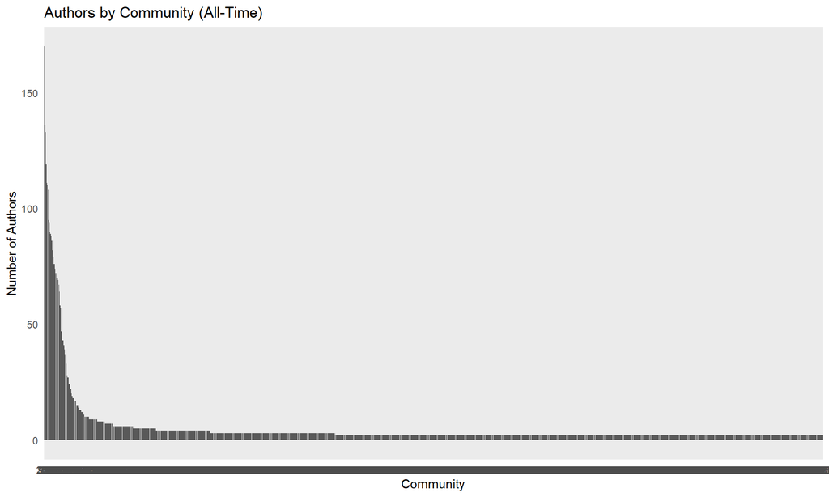

```r
p6 <- network_data %>%
  filter(node_type == "author", !is.na(all_time_communities), all_time_communities != 0) %>%
  count(all_time_communities) %>%
  ggplot(aes(x = reorder(factor(all_time_communities), -n), y = n)) +
  geom_col() +
  labs(title = "Authors by Community (All-Time)",
       x = "Community", y = "Number of Authors") +
  theme_minimal()

print(p6)
```

## Corpus Overview

The Royal Society Corpus contains the full text of scientific publications along with rich metadata.

Understanding this structure is essential for designing meaningful analyses.

Metadata is saved in the corpus object, and can be accessed with docvars(rsc_corpus)$METADATA.

```r
cat("Total documents in corpus:", ndoc(rsc_corpus), "\n")
```

```
## Total documents in corpus: 17520
```

```r
cat("Corpus docvar names:", paste(names(docvars(rsc_corpus)), collapse = ", "), "\n\n")
```

```
## Corpus docvar names: doc_id, issn, title, fpage, lpage, year, volume, journal, author, type, corpusBuild, doiLink, language, jrnl, decade, period, century, pages, sentences, tokens, visualizationLink, doi, jstorLink, hasAbstract, isAbstractOf, primaryTopic, primaryTopicPercentage, secondaryTopic,…
```

The metadata saved in the corpus includes:

**Document Identification & Bibliographic Info**

- doc_id: Unique identifier for each document in the corpus
- issn: International Standard Serial Number for the journal/publication
- title: Title of the scientific paper/article
- fpage/lpage: First page and last page numbers where the article appears
- year: Publication year
- volume: Journal volume number
- journal and jrnl: Name of the Royal Society publication, along with an abbreviated/shortened version
- author: Author(s), seperated by a | (pipe)

**Document Properties**

**Digital Infrastructure**

- corpusBuild: Version or build number of the corpus compilation
- doiLink: URL link to the Digital Object Identifier
- doi: The actual DOI string
- visualizationLink: Link to any digital visualizations of the document
- jstorLink: Link to JSTOR database entry (if available)

**Content Structure**

- hasAbstract: Boolean indicating whether the document has an abstract
- isAbstractOf: If this document IS an abstract, what it’s an abstract of

**Topic Classifications**

- primaryTopic: Main subject classification (computationally assigned)
- primaryTopicPercentage: Confidence/percentage/theta/θ for primary topic assignment
- secondaryTopic: Secondary subject classification
- secondaryTopicPercentage: Confidence/percentage/theta/θ for secondary topic

**Authorship Analysis**

- authors_list: Complete list of all authors (saved as a list)
- author_count: Number of authors on the paper
- is_multi_author: Boolean flag for whether it has multiple authors

### Authors

Understanding collaboration patterns helps us interpret later analyses of how single vs. multi-author works differ linguistically.

```r
# Display author summary stats

cat("Documents with authors:", sum(docvars(rsc_corpus)$author_count > 0), "\n")
```

```
## Documents with authors: 16229
```

```r
cat("Single-author documents:", sum(docvars(rsc_corpus)$author_count == 1), "\n")
```

```
## Single-author documents: 10491
```

```r
cat("Multi-author documents:", sum(docvars(rsc_corpus)$author_count > 1), "\n")
```

```
## Multi-author documents: 5738
```

```r
cat("Max authors per document:", max(docvars(rsc_corpus)$author_count), "\n")
```

```
## Max authors per document: 28
```

```r
cat("Min authors per document:", min(docvars(rsc_corpus)$author_count), "\n") # Some documents have no author infomration
```

```
## Min authors per document: 0
```

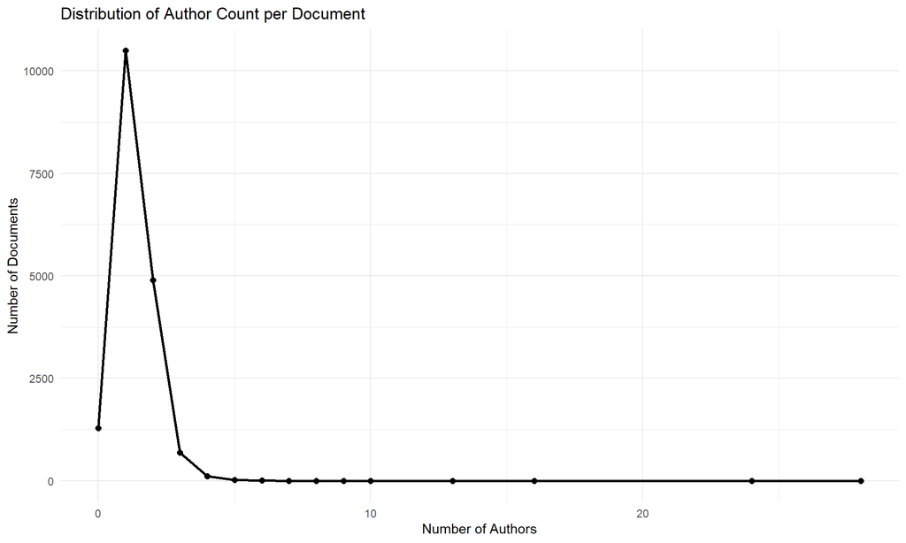

```r
# Documents by authorship
p4 <- docvars(rsc_corpus)$author_count %>%
  data.frame(author_count = .) %>%
  count(author_count) %>%
  ggplot(aes(x = author_count, y = n)) +
  geom_line(size = 1) +
  geom_point(size = 2) +
  labs(title = "Distribution of Author Count per Document",
       x = "Number of Authors", y = "Number of Documents") +
  theme_minimal()

p5 <- data.frame(
  decade = docvars(rsc_corpus)$decade,
  is_multi_author = docvars(rsc_corpus)$is_multi_author
) %>%
  group_by(decade, is_multi_author) %>%
  summarise(count = n(), .groups = "drop") %>%
  ggplot(aes(x = decade, y = count, fill = is_multi_author)) +
  geom_col(position = "dodge", alpha = 0.7) +
  labs(
    title = "Single vs Multi-Author Documents by Decade",
    x = "Decade", y = "Number of Documents",
    fill = "Multi-Author"
  ) +
  theme_minimal()

print(p4)
```

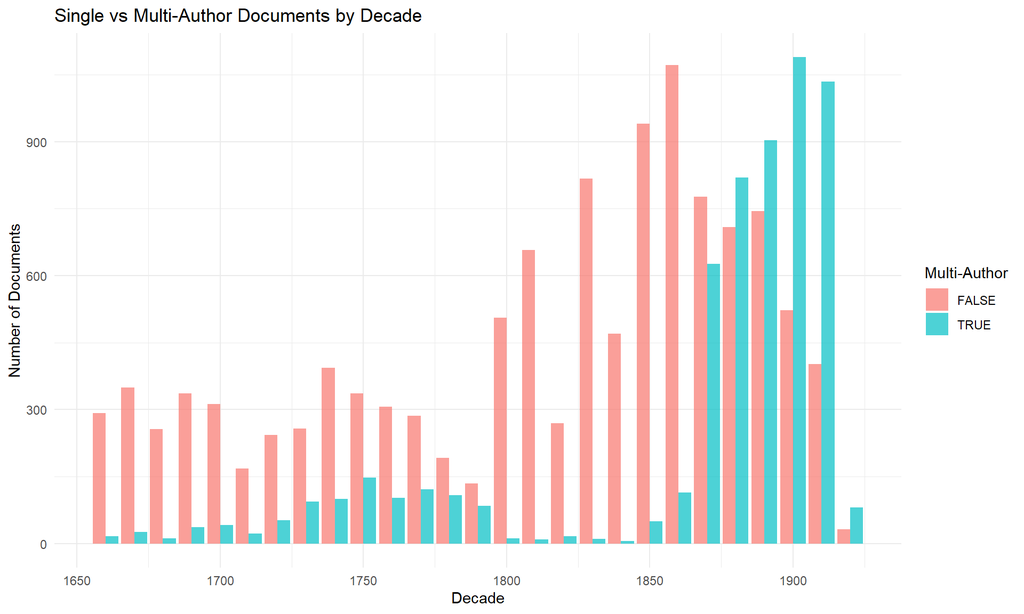

```r
print(p5)
```

### Topics

The RSC includes topic classifications that reveal the disciplinary structure of early modern science. These categories may reflect how scientific knowledge was organized in different historical periods.

```r
# Check topics
topic_values <- docvars(rsc_corpus, "primaryTopic")
cat("Unique primary topics (first 10):", paste(sort(unique(topic_values))[1:10], collapse = ", "), "\n")
```

```
## Unique primary topics (first 10): Agriculture, Anatomy 1, Anatomy 2, Astronomy, Atomic Physics, Biochemistry, Biography, Biology 1, Biology 2, Biology 3
```

```r
# physics_topics <- c("Atomic Physics", "Thermodynamics", "Fluid Dynamics")
# cat("Physics topics found:", paste(physics_topics[physics_topics %in% unique(topic_values)], collapse = ", "), "\n")
# cat("Number of physics docs:", sum(topic_values %in% physics_topics, na.rm = TRUE), "\n\n")

secondary_topic_values <- docvars(rsc_corpus, "secondaryTopic")
cat("Unique secondary topics (first 10):", paste(sort(unique(secondary_topic_values))[1:10], collapse = ", "), "\n")
```

```
## Unique secondary topics (first 10): Agriculture, Anatomy 1, Anatomy 2, Astronomy, Atomic Physics, Biochemistry, Biography, Biology 1, Biology 2, Biology 3
```

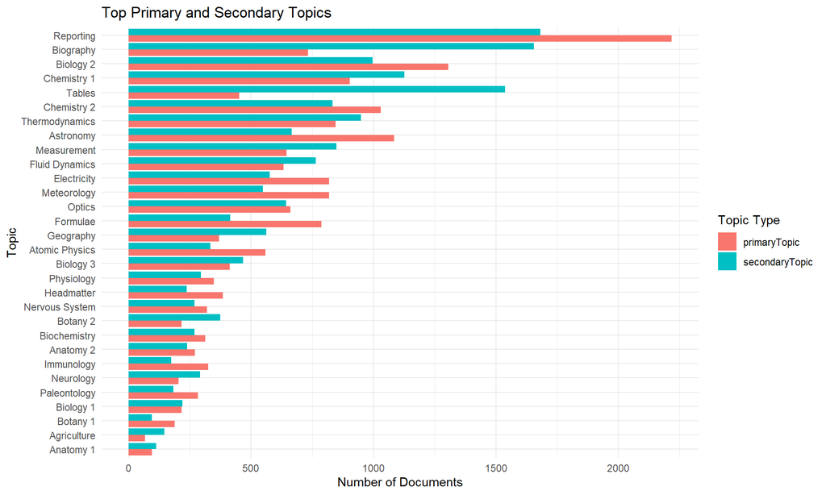

```r
# Combine counts for both topic types
topic_counts <- data.frame(primaryTopic = topic_values,
             secondaryTopic = secondary_topic_values) %>%
  tidyr::pivot_longer(cols = c(primaryTopic, secondaryTopic),
                      names_to = "TopicType", values_to = "Topic") %>%
  count(TopicType, Topic, sort = TRUE)


p3 <- topic_counts %>%
  ggplot(aes(x = reorder(Topic, n), y = n, fill = TopicType)) +
  geom_col(position = position_dodge()) +
  coord_flip() +
  labs(title = "Top Primary and Secondary Topics",
       x = "Topic", y = "Number of Documents", fill = "Topic Type") +
  theme_minimal()

print(p3)
```

### Temporal Distribution

The temporal distribution shows how the Royal Society’s publication patterns changed over three centuries, reflecting broader changes in scientific communication and institutional growth.

```r
# Check decade values
decade_values <- docvars(rsc_corpus, "decade")
cat("Unique decade values:", paste(sort(unique(decade_values)), collapse = ", "), "\n")
```

```
## Unique decade values: 1660, 1670, 1680, 1690, 1700, 1710, 1720, 1730, 1740, 1750, 1760, 1770, 1780, 1790, 1800, 1810, 1820, 1830, 1840, 1850, 1860, 1870, 1880, 1890, 1900, 1910, 1920
```

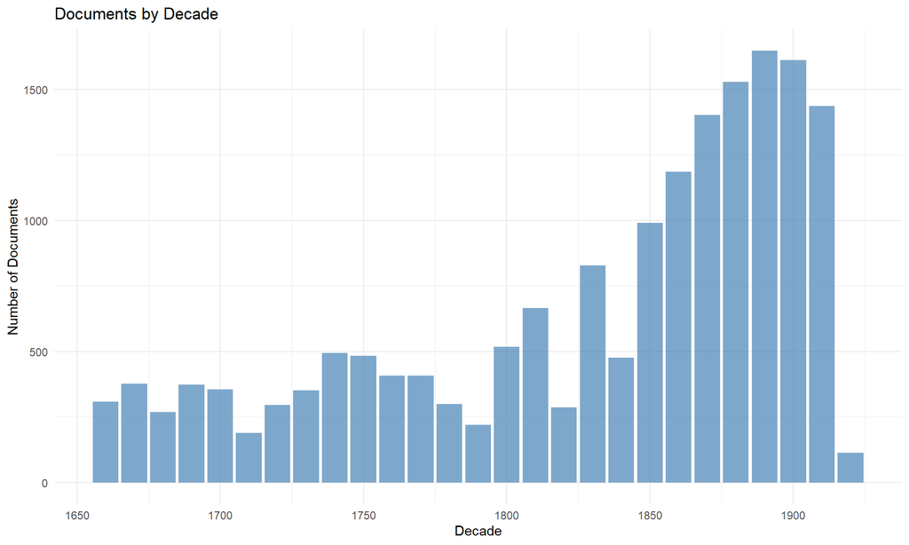

```r
# Documents by decade
p1 <- decade_values %>%
  data.frame(decade = decade_values) %>%
  ggplot(aes(x = decade)) +
  geom_bar(fill = "steelblue", alpha = 0.7) +
  labs(title = "Documents by Decade",
       x = "Decade", y = "Number of Documents") +
  theme_minimal()

print(p1)
```

## Publication types

Different document types serve different functions in scientific communication, from formal research articles to brief communications and abstracts.

```r
# Check document types
type_values <- docvars(rsc_corpus, "type")
cat("Unique document types:", paste(unique(type_values), collapse = ", "), "\n")
```

```
## Unique document types: speech, article, abstract, publication-announcement, report, astronomical-observation, lecture, errata, experiment, discussion, biography, magnetical-observation, notes, corrigenda, addendum, letter, list, paper-read, appendix, catalogue, preface, advertisement, fla, brv, a…
```

```r
cat("Number of article docs:", sum(type_values == "article", na.rm = TRUE), "\n\n")
```

```
## Number of article docs: 4503
```

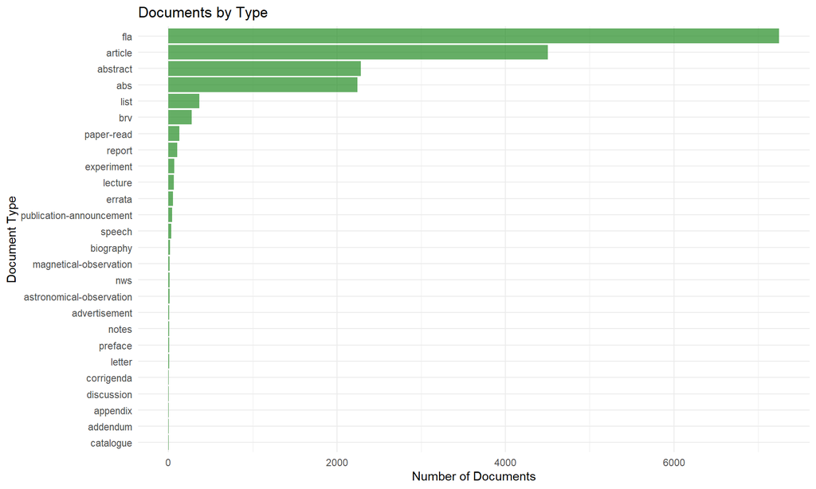

```r
# Documents by type
p2 <- type_values %>%
  data.frame(type = type_values) %>%
  count(type) %>%
  ggplot(aes(x = reorder(type, n), y = n)) +
  geom_col(fill = "forestgreen", alpha = 0.7) +
  coord_flip() +
  labs(title = "Documents by Type",
       x = "Document Type", y = "Number of Documents") +
  theme_minimal()

print(p2)
```

## Mixing perspectives

And, of course, we can look at one data type from the perspective of another. In this case, what were the types of documnets published over time.

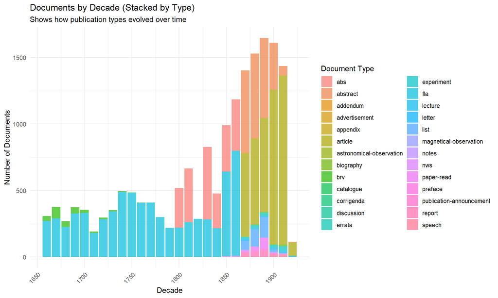

```r
# Documents by decade, stacked by type
p1_stacked <- data.frame(
  decade = docvars(rsc_corpus, "decade"),
  type = docvars(rsc_corpus, "type")
) %>%
  ggplot(aes(x = decade, fill = type)) +
  geom_bar(alpha = 0.7) +
  labs(title = "Documents by Decade (Stacked by Type)",
       subtitle = "Shows how publication types evolved over time",
       x = "Decade", y = "Number of Documents",
       fill = "Document Type") +
  theme_minimal() +
  theme(axis.text.x = element_text(angle = 45, hjust = 1))

print(p1_stacked)
```

# Understanding the Subsetting Functions

The power of metadata-driven analysis lies in our ability to create focused subsets for comparison. The helper functions in this workshop allow flexible filtering by any combination of metadata dimensions.

## How the Subsetting Works

The subset_corpus() function acts as a master controller that can filter by:

- Temporal criteria: Specific years, decades, or date ranges
- Document types: Articles, abstracts, proceedings, etc.
- Topics: Primary or secondary subject classifications
- Authorship patterns: Single vs. multi-author works
- Network communities: Authors from specific intellectual communities
- Individual authors: Works by named scientists

This flexibility enables complex, multi-dimensional comparisons that would be impossible with text alone.

## Test Individual Subsetting Functions

```r
# Test date subsetting directly
test_1900s <- subset_by_date(rsc_corpus, decade = 1900)
cat("Direct decade subsetting (1900s):", ndoc(test_1900s), "documents\n")
```

```
## Direct decade subsetting (1900s): 1612 documents
```

```r
# Test type subsetting directly
test_articles <- subset_by_type(rsc_corpus, "article")
cat("Direct type subsetting (articles):", ndoc(test_articles), "documents\n")
```

```
## Direct type subsetting (articles): 4503 documents
```

```r
# Test topic subsetting directly
test_biology <- subset_by_topic(rsc_corpus, "Biology 1")
cat("Direct topic subsetting (biology):", ndoc(test_biology), "documents\n")
```

```
## Direct topic subsetting (biology): 216 documents
```

```r
# Or create lists of topics
test_topics <- unique(docvars(rsc_corpus)$primaryTopic[grep("biology", docvars(rsc_corpus)$primaryTopic, ignore.case = TRUE)])
test_topics_list <- subset_by_topic(rsc_corpus, test_topics)
cat("Direct topic subsetting for", test_topics, ":", ndoc(test_topics_list), "documents\n")
```

```
## Direct topic subsetting for Biology 3 Biology 1 Biology 2 : 1935 documents
```

```r
# Test author count subsetting directly
test_multi_author <- subset_by_author_count(rsc_corpus, multi_author = TRUE)
cat("Direct multi-author subsetting:", ndoc(test_multi_author), "documents\n")
```

```
## Direct multi-author subsetting: 5738 documents
```

## Example Subsetting Operations

These examples demonstrate the building blocks for all subsequent analyses. Each represents a different way of slicing the corpus to address specific research questions.

```r
# Example 1: Subset by decade (1900s) with debugging to show how filtering is working

corpus_1900s <- subset_corpus(rsc_corpus, decade = 1900, debug = TRUE)
```

```
## Starting with 17520 documents
## After date filtering: 1612 documents
## After type filtering: 1612 documents
## After topic filtering: 1612 documents
## After journal filtering: 1612 documents
## After author filtering: 1612 documents
## After author count filtering: 1612 documents
```

```r
cat("1900s corpus:", ndoc(corpus_1900s), "documents\n\n")
```

```
## 1900s corpus: 1612 documents
```

```r
# Example 2: Subset by document type (articles only) with debugging
corpus_articles <- subset_corpus(rsc_corpus, doc_types = "article", debug = TRUE)
```

```
## Starting with 17520 documents
## After date filtering: 17520 documents
## After type filtering: 4503 documents
## After topic filtering: 4503 documents
## After journal filtering: 4503 documents
## After author filtering: 4503 documents
## After author count filtering: 4503 documents
```

```r
cat("Articles only:", ndoc(corpus_articles), "documents\n\n")
```

```
## Articles only: 4503 documents
```

```r
# Example 3: Multi-author documents with debugging
corpus_multi_author <- subset_corpus(rsc_corpus, multi_author = TRUE, debug = TRUE)
```

```
## Starting with 17520 documents
## After date filtering: 17520 documents
## After type filtering: 17520 documents
## After topic filtering: 17520 documents
## After journal filtering: 17520 documents
## After author filtering: 17520 documents
## After author count filtering: 5738 documents
```

```r
cat("Multi-author documents:", ndoc(corpus_multi_author), "documents\n\n")
```

```
## Multi-author documents: 5738 documents
```

Here are some more other examples without debug for cleaner output.

```r
# Example 4: Subset by topic (Physics-related)
physics_topics <- c("Atomic Physics")
corpus_physics <- subset_corpus(rsc_corpus, topics = physics_topics)
cat("Physics topics:", ndoc(corpus_physics), "documents\n")
```

```
## Physics topics: 560 documents
```

```r
# Example 5: Combined subsetting (1900s + physics + articles)
corpus_1900s_physics <- subset_corpus(rsc_corpus,
                                     decade = 1900,
                                     doc_types = "article",
                                     topics = physics_topics)
cat("1900s physics articles:", ndoc(corpus_1900s_physics), "documents\n")
```

```
## 1900s physics articles: 94 documents
```

```r
# Example 6: Documents by specific authors
example_authors <- c("Sir William Ramsay, K. C. B., F. R. S.", "Professor C. Niven, F. R. S.")
corpus_by_authors <- subset_corpus(rsc_corpus, authors = example_authors)
cat("Documents by example authors:", ndoc(corpus_by_authors), "documents\n")
```

```
## Documents by example authors: 35 documents
```

```r
# Example 7: Documents from specific communities (using separate network data)
example_communities <- c(1, 2)
corpus_communities_alltime <- subset_corpus(rsc_corpus, communities = example_communities)
cat("Documents from communities 1 & 2 (all-time):", ndoc(corpus_communities_alltime), "documents\n")
```

```
## Documents from communities 1 & 2 (all-time): 242 documents
```

```r
# Example 8: Community analysis for specific time period
corpus_communities_1900s <- subset_corpus(rsc_corpus, communities = c(1, 2),
                                         time_slice = "slice_1875_1924")
cat("Documents from communities 1 & 2 (1875-1924 slice):", ndoc(corpus_communities_1900s), "documents\n")
```

```
## Documents from communities 1 & 2 (1875-1924 slice): 344 documents
```

```r
# Example 9: Get authors from specific communities first
authors_comm1 <- get_authors_from_communities(communities = 1, time_slice = "all_time_communities")
cat("Authors in community 1:", length(authors_comm1), "authors\n")
```

```
## Authors in community 1: 74 authors
```

```r
if (length(authors_comm1) > 0) {
  corpus_comm1_authors <- subset_corpus(rsc_corpus, authors = authors_comm1[1:min(3, length(authors_comm1))])
  cat("Documents by first 3 authors from community 1:", ndoc(corpus_comm1_authors), "documents\n")
}
```

```
## Documents by first 3 authors from community 1: 7 documents
```

Finally, once a corpus is subset, you can examine the documents that remain.

```r
corpus_comm1_authors
```

```
## Corpus consisting of 7 documents and 32 docvars.
## rspa_1905_0002 :
## "The Boring of the Simplon Tunnel , etc. 29* Hughes Medal . T..."
##
## rspa_1905_0006 :
## "]\gt ; On the -active . By the Hon. B. J. sTIiuTT , Fellow o..."
##
## rspa_1906_0008 :
## "122 A Gas Calorimeter . By C. V. Boys , F.R.S. ( Received De..."
##
## rspa_1912_0087 :
## "340 Experiments with Rotating Liquid Films . By C. Y. Boys ,..."
##
## rspl_1899_0103 :
## "Photography of S\amp ; c. \#171 ; Photography of Sound-waves..."
##
## rspl_1901_0096 :
## "The Anomalous Dispersion of Sodium Vapour . " The Anomalous ..."
##
## [ reached max_ndoc ... 1 more document ]
```

```r
full_text_test <- as.character(corpus_comm1_authors)[3]   # get the third document
cat(full_text_test) # print the whole thing
```

```
## 122 A Gas Calorimeter .
## By C. V. Boys , F.R.S. ( Received December 7 , \#151 ; Read December 7 , 1905 .
## ) In the report of the gas section of the Electrical and Gas Exhibition held at the Crystal Palace in 1884 , there is an illustrated account of a gas calorimeter devised by Mr. F. W. Hartley for the purpose of testing the calorific value of the gas used in the cooking and heating apparatus shown …
## This report , which is rather inaccessible , may be seen in the library of the Patent Office in Southampton Buildings , Chancery Lane , and its catalogue number is 15,262 .
## In this instrument the gas to be examined is passed through a delicate meter and governor , after which it is burned in a Bunsen burner in the instrument .
## The heat is taken from the products of combustion and the unchanged air by means of a stream of water , the rate of flow and rise of temperature of which are determined .
## From these observations the calorific value of the gas can be deduced .
## Mr. Hartley considered the very small corrections due to the effluent gas being slightly different in temperature from the surrounding air , also corrections due to adventitious loss or gain of heat , and to the change in the specific heat of water with temperature .
## The paper unfortunately occupies only five pages , and the construction of the details of the instrument can only be inferred from the figure .
## The Hartley type of apparatus has in the last 14 years become wrell known owing to the sale of the excellent instrument designed by Junkers .
## I have had occasion to use this instrument a good deal , and while I in no way criticise it on the ground of want of accuracy , I have found it unwieldy and inconvenient in use .
## If the water and gas supply and the water escape as provided suit the surroundings , well and good , if not , pipes must be taken round to adapt the surroundings to the instrument .
## The thermometers for the inlet and outlet water are at very different levels and the instrument is inordinately high , so that if placed on a table or by the side of an ordinary sink the observer has to keep climbing up and down in order to read the two thermometers and make notes .
## The thermometers and the reading-glasses provided are admirable ; in this respect improvement appears impossible , but the readings easily made to 1/ 100 ' C. are vitiated by the constant spasmodic jumps of the indication of the outlet thermometer in consequence of warmer and cooler streaks in th…
## These irregularities may amount to 1/ 10 ' more or less , and A Gas Calorimeter .
## though they are not enough to introduce error of consequence , they give the opportunity to different observers to read on the whole high or low , and they may encourage the idea that accuracy in reading the thermometer is not of much consequence .
## The water content of the instrument is 1700 c.c. , and so , with a usual rate of flow , from two to three minutes are required to change the water .
## This large content and the consequent time of change must be taken into account if the temperature of the inlet water is undergoing a small but steady variation at a rate sufficient to be observed in this time .
## Simultaneous measures of inlet and outlet temperature would not give the true rise of temperature ; to approximate to this the inlet readings should be taken two or three minutes before the corresponding outlet readings , the interval depending on the rate of flow .
## A more serious objection to a large water capacity is the time that the observer must wait before the final temperature is reached , the last creeping up being very slow .
## I have also experimented with two other makes of gas calorimeter , but I have found that they are little more than copies of the Junkers instrument .
## The spasmodic variations of the outlet readings are quite as great ; the water content in one of them is nearly 6 litres , and nothing has been done in either to reduce the inconvenient height or to increase the facility with which they may be adapted to their surroundings .
## Professor Threlfall has designed a calorimeter with the view specially to keeping a continuous record of the variation of the calorific power of gas .
## I have not seen this instrument or any complete account of it , but Professor Threlfall has informed me that he has kept the water content as low as he could .
## I have had to examine existing calorimeters in consequence of a change in the law with regard to the testing of gas in London .
## From January 1 next the calorific value is to be taken , and it is the duty of the gas referees to prescribe the mode of testing .
```

[output cut: 82 more lines]

# Analysing Text

For this portion of the workbook we will use the Quantitative Text Analysis(QTA)/Natural Language Processing(NLP) library Quanteda.

Quanteda (and many/most NLP packages) work with objects called Document Feature Matrices (or Document Term Matrices). These are, essentially, *very* large spreadsheets where every row represents a document and every column is a word (of all the words) in all of the documents. A toy example:

```r
# Create a corpus - just like the RSC - of three simple sentences
test_corpus <- corpus(c("I like cats", "Cats are nice", "I am happy"))

# Create document feature matrix of our corpus
test_dfm <- tokens(test_corpus) %>%
  dfm()

# And let's look at it
print(test_dfm)
```

```
## Document-feature matrix of: 3 documents, 7 features (57.14% sparse) and 0 docvars.
##        features
## docs    i like cats are nice am happy
##   text1 1    1    1   0    0  0     0
##   text2 0    0    1   1    1  0     0
##   text3 1    0    0   0    0  1     1
```

It is the frequency and relationship of these features (tokens, words) that is central to NLP. We will, therefore, be analysing DFMs which are quantitative representation of our documents - figuratively “bags of words.” *N.B.* This also means that the human-readable text is no longer there. If you want to read a document you will need to go back to the corpus object.

For example, it becomes easy (and computationally less difficult) to identify the most frequent words (or other features):

```r
topfeatures(test_dfm)
```

```
##     i  cats  like   are  nice    am happy
##     2     2     1     1     1     1     1
```

It is, therefore, a DFM of the RSC that we will analyse going forward. However, to do this we first need to construct it.

*N.B.:* this can take a few minutes, depending on computational resources. An already constructed DFM can be loaded by commenting out code:

```r
# rsc_dfm <- readRDS("../data/rsc_dfm.RDS")

start_time <- Sys.time()

# Tokenise corpus, while removing punctuation, numbers, symbols, and stopwords as well as lowercasing everything
rsc_tokens <- tokens(rsc_corpus, remove_punct = TRUE, remove_numbers = TRUE,
                      remove_symbols = TRUE) %>%
  tokens_tolower() %>%
  tokens_remove(stopwords("english"))

# Document-feature matrix
rsc_dfm <- dfm(rsc_tokens)

end_time <- Sys.time()
cat("Total time taken to tokenise and create DFM:")
```

```
## Total time taken to tokenise and create DFM:
```

```r
print(end_time-start_time)
```

```
## Time difference of 1.413795 mins
```

```r
#saveRDS(rsc_dfm, file = "../data/rsc_dfm.RDS")
```

And now we can begin to analyse the text.

```r
topfeatures(rsc_dfm, n = 50)
```

```
##            s         #151          one          may          two            c
##       170924       169065       165252       154730       148620       124684
##            p          fig        first        found         made        water
##       107637        99679        97611        92149        91682        89598
##         part         also         time         upon            x  experiments
##        87444        86989        85692        78056        74734        73130
##            b        small         case         much            e      surface
##        72577        72527        70291        64426        64093        64061
##            m         acid  temperature            d          air        given
##        63858        63635        63525        61134        60331        60246
##      results         form          can observations        plate            o
##        59013        58802        58214        57772        56956        56915
##        great            h            f        point           mr          now
##        56743        56376        55577        55477        55026        54978
##          per     obtained         thus    different            n    therefore
##        54890        54475        53780        53618        53351        52965
##        three       number
##        52003        51990
```

However, we can quickly see that many of these “words” are not meaningful. We therefore may also want to create our own constum stopword list.

```r
######################################
# A custom list of stopwords (and symbols).
# YOU MAY WANT TO UPDATE THIS TO ADD AND/OR REMOVE WORDS AS YOU ANALYSE DATA YOURSELF
######################################

custom_stopwords <- c("fig", "page", "pp", "vol", "etc", "viz", "mr", "dr", "prof", "#151",
                  "#183", "#169", "also", "upon", "one", "two", "three", "four", "five", "six", "seven",
                  "eight", "nine", "ten", "may", "can", "+", "-", "~", "=", "^",
                  "per" ,"cent", "royal", "society", "phil", "trans", "8vo", "|", "results",
                  "another", "professor", "roy", "soc", "first", "part", "much", "given",
                  "great", "now", "must", "thus", "therefore", "seen", "however", "amp",
                  "second", "taken", "without", "many", "well", "f.r.s.", "table", "ii",
                  "iii", "iv", "v", "vi", "vii", "viii", "ix", "mdash", "figs",
                  letters)

rsc_dfm <- dfm_remove(rsc_dfm,  pattern = custom_stopwords)

topfeatures(rsc_dfm, n = 50)
```

```
##        found         made        water         time  experiments        small
##        92149        91682        89598        85692        73130        72527
##         case      surface         acid  temperature          air         form
##        70291        64061        63635        63525        60331        58802
## observations        plate        point     obtained    different       number
##        57772        56956        55477        54475        53618        51990
##         less     solution        large       series        light      present
##        49833        48634        48591        47872        46837        46699
##         side     observed         line    following   experiment       effect
##        45838        45525        43629        43038        43008        42930
##        lines         mean        place         tube     pressure       action
##        42450        42196        41761        41515        41413        40916
##        value        parts          end        whole         long        cells
##        40849        40773        40119        39580        39536        38716
##       little        paper         used        shown       length      general
##        38070        37839        36975        36309        35685        35386
##        order   difference
##        35266        34799
```

You can recreate (or reload) the DFM at any point if you think you’ve removed too many.

## 1. Baseline: Text Without Metadata Context

**The question we can ask**: What are the most common concepts and patterns discussed by the Royal Society overall?

**What this may reveal**: Basic vocabulary, general themes, and surface-level patterns in scientific discourse across the entire corpus (multi-topic) and time period (multi-century).

**Critical limitation**: Without metadata, we have little context for interpretation. We can see what scientists and researchers wrote about, but not when, who wrote it, why certain terms appear together, or how usage patterns changed over time.

This baseline represents the starting point for any text analysis – but also demonstrates why metadata is essential for meaningful interpretation.

**N.B.**: This is a moderately large dataset. Creating and analying the text computationally can take a bit of time. It’s not at the point where high performance computing is necessary, but it may take a few minutes on a laptop.

```r
# Most frequent terms
cat("Top 20 Most Frequent Terms (All Documents):\n")
```

[output not shown]

```r
topfeatures(rsc_dfm, 50) %>% print()
```

```
##        found         made        water         time  experiments        small
##        92149        91682        89598        85692        73130        72527
##         case      surface         acid  temperature          air         form
##        70291        64061        63635        63525        60331        58802
## observations        plate        point     obtained    different       number
##        57772        56956        55477        54475        53618        51990
##         less     solution        large       series        light      present
##        49833        48634        48591        47872        46837        46699
##         side     observed         line    following   experiment       effect
##        45838        45525        43629        43038        43008        42930
##        lines         mean        place         tube     pressure       action
##        42450        42196        41761        41515        41413        40916
##        value        parts          end        whole         long        cells
##        40849        40773        40119        39580        39536        38716
##       little        paper         used        shown       length      general
##        38070        37839        36975        36309        35685        35386
##        order   difference
##        35266        34799
```

```r
# Most frequent n-grams
rsc_bigrams <- rsc_tokens %>%
  tokens_remove(c(custom_stopwords)) %>%
  tokens_ngrams(n = 2) %>%
  dfm()
cat("\nTop 10 Most Frequent Bigrams:\n")
```

[output not shown]

```r
topfeatures(rsc_bigrams, 50) %>% print()
```

```
##              carbonic_acid          observations_made
##                       7481                       6983
##           experiments_made             sulphuric_acid
##                       6947                       6469
##                takes_place                      co_co
##                       6373                       5708
##             f.r.s_received                      rh_rh
##                       5385                       5334
##                 take_place           specific_gravity
##                       5186                       4696
##                      de_la                nitric_acid
##                       4543                       4480
##                      gt_gt               right_angles
##                       3754                       3676
##          hydrochloric_acid             small_quantity
##                       3601                       3579
##                     let_us         transverse_section
##                       3502                       3388
##                 took_place             carbon_dioxide
##                       3298                       3213
##         series_experiments            distilled_water
##                       3136                       3116
## philosophical_transactions                cub_centims
##                       3110                       2876
##              specific_heat                inches_long
##                       2786                       2785
##               large_number                 right_side
##                       2747                       2682
##                 glass_tube                  left_side
##                       2628                       2608
##              inch_diameter                  years_ago
##                       2546                       2507
##              present_paper          already_described
##                       2441                       2437
##                   made_use                 mean_value
##                       2320                       2275
##             nervous_system            different_parts
##                       2260                       2257
##                acetic_acid                 right_left
##                       2254                       2226
##                 short_time              upper_surface
##                       2178                       2127
##                spinal_cord                like_manner
##                       2124                       2095
##                  read_june           horizontal_force
##                       2033                       2023
##          positive_negative             magnetic_force
##                       2007                       2003
##              atomic_weight              straight_line
##                       1993                       1992
```

## 2. Temporal Metadata: Historical Evolution

**Research Questions Enabled**: How did scientific concepts evolve over time? When did new terminology emerge?

Comparing language in the 18th and 19th centuries.

```r
# Create by century
dfm_1700s <- subset_corpus(rsc_dfm, century = 1700)
dfm_1800s <- subset_corpus(rsc_dfm, century = 1800)

# # Create or by start and end year
# dfm_1700s <- subset_corpus(rsc_dfm, start_year = 1700, end_year = 1799)
# dfm_1800s <- subset_corpus(rsc_dfm, start_year = 1800, end_year = 1899)

# Overview of temporal subsets
cat("\n1700s Corpus:\n")
```

```
##
## 1700s Corpus:
```

```r
cat("Documents:", ndoc(dfm_1700s), "\n")
```

```
## Documents: 3505
```

```r
cat("Tokens:", sum(ntoken(dfm_1700s)), "\n\n")
```

```
## Tokens: 3544405
```

```r
cat("\n1800s Corpus:\n")
```

```
##
## 1800s Corpus:
```

```r
cat("Documents:", ndoc(dfm_1800s), "\n")
```

```
## Documents: 9528
```

```r
cat("Tokens:", sum(ntoken(dfm_1800s)), "\n")
```

```
## Tokens: 17708282
```

```r
# Compare top terms
cat("\nTop 15 Terms in 1700s:\n")
```

```
##
## Top 15 Terms in 1700s:
```

```r
topfeatures(dfm_1700s, 15) %>% print()
```

```
##         time        water          air         made        found        small
##        17211        16141        15780        15666        13811        10617
##       little        parts      several         near     observed     quantity
##         9348         8627         8231         7844         7720         7376
## observations    different  experiments
##         7310         7202         7199
```

```r
cat("Top 15 Terms in 1800s:\n")
```

```
## Top 15 Terms in 1800s:
```

```r
topfeatures(dfm_1800s, 15) %>% print()
```

```
##        water        found         made         acid         time  experiments
##        51348        49617        49485        46059        44836        43241
##      surface        plate        small         case         form  temperature
##        42747        40509        39858        39591        39514        38399
## observations        point     obtained
##        37555        32828        32694
```

This is quite insightful at first glance, but top features alone only tell us so much. What about less frequent, but completely new words? For that we can look at relative frequency (keyness).

```r
# Compare 1700s vs 1800s using keyness analysis
# This is statistically rigorous and much simpler than manual frequency ratios

# Combine the DFMs and add period labels
combined_dfm <- rbind(dfm_1700s, dfm_1800s)
docvars(combined_dfm, "period") <- c(rep("1700s", ndoc(dfm_1700s)),
                                     rep("1800s", ndoc(dfm_1800s)))

# Calculate keyness (target = TRUE means 1800s vs 1700s)
keyness_results <- textstat_keyness(combined_dfm,
                                    target = docvars(combined_dfm, "period") == "1800s")

# Terms that became much more prominent in 1800s
cat("\nTerms most distinctive of 1800s (became much more frequent):\n")
```

```
##
## Terms most distinctive of 1800s (became much more frequent):
```

```r
keyness_results %>%
  filter(chi2 > 0) %>%
  arrange(desc(chi2)) %>%
  head(10) %>%
  print()
```

```
##        feature     chi2 p n_target n_reference
## 1  temperature 5157.180 0    38399        1291
## 2        plate 4429.262 0    40509        1977
## 3     obtained 4240.018 0    32694        1186
## 4        cells 3856.673 0    23972         458
## 5       action 3263.026 0    29075        1364
## 6          gas 3196.337 0    17911         184
## 7      current 2938.967 0    19853         514
## 8     hydrogen 2681.901 0    13912          48
## 9     spectrum 2659.093 0    15824         244
## 10    pressure 2598.419 0    21104         847
```

```r
# Terms that were more characteristic of 1700s (declined in 1800s)
cat("\nTerms most distinctive of 1700s (declined in 1800s):\n")
```

```
##
## Terms most distinctive of 1700s (declined in 1800s):
```

```r
keyness_results %>%
  filter(chi2 < 0) %>%
  arrange(chi2) %>%
  head(10) %>%
  print()
```

```
##    feature       chi2 p n_target n_reference
## 1     fire -11765.220 0      948        3383
## 2      tab -11480.129 0      436        2824
## 3      air -11192.027 0    28905       15780
## 4   center  -9275.596 0      138        2037
## 5     thro  -7637.516 0       14        1548
## 6   letter  -7451.148 0     2441        3453
## 7     hath  -7412.119 0       17        1507
## 8      tho  -6754.884 0     1154        2433
## 9   people  -6715.700 0      435        1833
## 10    till  -6703.356 0     4928        4552
```

### Interpreting Temporal Results: Look for:

- Emerging terminology: New scientific concepts that appeared in the 1800s
- Declining usage: 18th-century terms that became less common
- Persistent concepts: Terms that remained important across both periods

This analysis can reveal scientific developments like the emergence of electromagnetic theory, advances in chemistry, or new measurement techniques.

Quite useful! So here’s another example:

```r
# # Create or by start and end year
dfm_1600s <- subset_corpus(rsc_dfm, start_year = 1600, end_year = 1700)
dfm_1700s <- subset_corpus(rsc_dfm, start_year = 1700, end_year = 1799)

# Combine the DFMs and add period labels
combined_dfm <- rbind(dfm_1600s, dfm_1700s)
docvars(combined_dfm, "subset_") <- c(rep("1600s", ndoc(dfm_1600s)),
                                     rep("1700s", ndoc(dfm_1700s)))

# Calculate keyness (target = TRUE means 1600s vs 1600s)
keyness_results <- textstat_keyness(combined_dfm,
                                    target = docvars(combined_dfm, "subset_") == "1700s")

# Terms that became much more prominent in 1700s
cat("\nTerms most distinctive of 1700s (became much more frequent):\n")
```

```
##
## Terms most distinctive of 1700s (became much more frequent):
```

```r
keyness_results %>%
  filter(chi2 > 0) %>%
  arrange(desc(chi2)) %>%
  head(10) %>%
  print()
```

```
##        feature     chi2 p n_target n_reference
## 1       nearly 931.9806 0     3826          85
## 2        ditto 824.7578 0     2843           2
## 3  electricity 759.9774 0     2660           7
## 4         acid 648.7317 0     4674         385
## 5         feet 631.3241 0     5340         519
## 6        point 621.0990 0     6464         743
## 7  thermometer 593.8982 0     2584          75
## 8       degree 561.6209 0     4747         461
## 9         tube 547.1187 0     3865         311
## 10       state 537.8235 0     3555         263
```

```r
# Terms that were more characteristic of 1600s (declined in 1800s)
cat("\nTerms most distinctive of 1600s (declined in 1800s):\n")
```

```
##
## Terms most distinctive of 1600s (declined in 1800s):
```

```r
keyness_results %>%
  filter(chi2 < 0) %>%
  arrange(chi2) %>%
  head(10) %>%
  print()
```

```
##       feature      chi2 p n_target n_reference
## 1        hath -4262.741 0     1507        2734
## 2        self -2853.928 0      858        1712
## 3      author -2101.791 0     1791        2057
## 4      divers -1748.733 0      353         903
## 5        doth -1547.854 0      290         779
## 6       saith -1547.407 0      106         592
## 7         yet -1447.228 0     6257        3891
## 8   discourse -1313.313 0      195         613
## 9  concerning -1236.637 0     1751        1611
## 10       numb -1216.464 0      106         491
```

## 3. Network/Community Metadata: Intellectual Communities

**Research Questions Enabled:**

- How do different scholarly communities use language differently?
- What concepts are community-specific vs. shared across scientific networks?
- How do intellectual networks influence the spread of terminology?
- Which communities serve as bridges between different scientific domains?

**Methodological Insight:** Network metadata reveals the social structure underlying scientific knowledge production. Different communities of scientists may develop distinct vocabularies, research methods, or ways of describing phenomena—even when studying related topics.

```r
# NB: Community zero represents isolates - needs to be dropped!
# Get the largest communities for meaningful comparison
large_communities <- network_data %>%
  filter(all_time_communities != 0) %>%
  filter(node_type == "author", !is.na(all_time_communities)) %>%
  count(all_time_communities, sort = TRUE) %>%
  head(3) %>%
  pull(all_time_communities)

cat("Analyzing communities:", paste(large_communities, collapse = ", "), "\n\n")
```

```
## Analyzing communities: 97, 210, 348
```

```r
# Create community-based subsets
dfm_comm1 <- subset_corpus(rsc_dfm, communities = large_communities[1])
dfm_comm2 <- subset_corpus(rsc_dfm, communities = large_communities[2])

# Overview of community subsets
cat("Community", large_communities[1], "Corpus:\n")
```

```
## Community 97 Corpus:
```

```r
cat("Documents:", ndoc(dfm_comm1), "\n")
```

```
## Documents: 448
```

```r
cat("Tokens:", sum(ntoken(dfm_comm1)), "\n")
```

```
## Tokens: 525482
```

```r
cat("\nCommunity", large_communities[2], "Corpus:\n")
```

```
##
## Community 210 Corpus:
```

```r
cat("Documents:", ndoc(dfm_comm2), "\n")
```

```
## Documents: 205
```

```r
cat("Tokens:", sum(ntoken(dfm_comm2)), "\n\n")
```

```
## Tokens: 557670
```

```r
# Compare vocabularies
cat("Top 15 Terms in Community", large_communities[1], ":\n")
```

```
## Top 15 Terms in Community 97 :
```

```r
topfeatures(dfm_comm1, 15) %>% print()
```

```
##         time          air         made          sun        water        found
##         3230         2612         2596         2037         2036         1918
##        ditto observations        point     distance        equal     observed
##         1900         1718         1666         1548         1477         1410
##        small         less       little
##         1349         1261         1223
```

```r
cat("\nTop 15 Terms in Community", large_communities[2], ":\n")
```

```
##
## Top 15 Terms in Community 210 :
```

```r
topfeatures(dfm_comm2, 15) %>% print()
```

```
##       cells       found        side        case     surface development
##        4116        1829        1443        1413        1408        1387
##        form        time       blood    solution     section       stage
##        1371        1353        1325        1247        1233        1219
##       organ     present        body
##        1213        1209        1178
```

```r
# Find community-distinctive terms using keyness
combined_dfm <- rbind(dfm_comm1, dfm_comm2)
docvars(combined_dfm, "subset") <- c(rep("subset1", ndoc(dfm_comm1)),
                                        rep("subset2", ndoc(dfm_comm2)))

# Calculate keyness
keyness_results <- textstat_keyness(combined_dfm,
                                  target = docvars(combined_dfm, "subset") == "subset1")

cat("\nTerms most distinctive of Community", large_communities[1], ":\n")
```

```
##
## Terms most distinctive of Community 97 :
```

```r
keyness_results %>%
  filter(chi2 > 0) %>%
  arrange(desc(chi2)) %>%
  head(10) %>%
  print()
```

```
##     feature      chi2 p n_target n_reference
## 1       air 2157.8588 0     2612         226
## 2       sun 2084.5072 0     2037          27
## 3     ditto 1801.4762 0     1900          75
## 4  distance 1038.8083 0     1548         240
## 5      moon 1014.9637 0      967           4
## 6     earth 1005.4311 0      975          10
## 7   gravity  930.0603 0      964          32
## 8     equal  922.9951 0     1477         263
## 9      time  888.8860 0     3230        1353
## 10    angle  866.9252 0     1100         112
```

```r
cat("\nTerms most distinctive of Community", large_communities[2], ":\n")
```

```
##
## Terms most distinctive of Community 210 :
```

```r
keyness_results %>%
  filter(chi2 < 0) %>%
  arrange(chi2) %>%
  head(10) %>%
  print()
```

```
##        feature       chi2 p n_target n_reference
## 1        cells -3697.0602 0       68        4116
## 2  development -1075.4724 0       86        1387
## 3        stage -1067.2423 0       29        1219
## 4        nerve -1047.0617 0       20        1171
## 5        organ -1034.2975 0       39        1213
## 6        layer  -937.1031 0        4        1006
## 7    posterior  -932.1223 0        8        1013
## 8         cell  -924.0093 0       28        1064
## 9     anterior  -880.5515 0        3         943
## 10      dorsal  -871.4113 0        0         924
```

### Interpreting Community Results: The keyness analysis reveals:

- Community-specific vocabularies: Terms that strongly characterise each intellectual network
- Disciplinary boundaries: How different scientific domains maintain distinct languages
- Methodological differences: Communities may prefer different research approaches or instruments
- Theoretical orientations: Distinct ways of conceptualising similar phenomena

These differences reflect how scientific communities develop their own research traditions, methodological preferences, and ways of understanding the natural world.